# **健身房团购分析报告**

DATA MINING GROUP 1

1 Apr 2019

### **一、背景介绍**

在健身房健身是时下较为潮流的保健养生方式之一，越来越多城市人选择前往健身房健身锻炼。在健身时，健身者希望得到更好的健身条件，这继而引申出诸多问题，如何选择一个环境优良、价格低廉而且成效显著的健身房，是当下待迫切解决的最大问题。  
以下对网站上抓取的1581条数据进行分析，通过建立线性回归模型解释影响目前健身房团购数的因素，得到合适的选择结果和预测。

### **二、变量分析**

#### **1.因变量**

在本次分析中，我们采用健身房的实际团购数作为模型的因变量，属于连续变量，取值范围为0~976。团购数直接反映的是健身房的使用次数以及健身者的选择情况。

#### **2.自变量**

**(1) 标题**

标题描述的是商家的自我描述，指明了健身房的名字、类型和位置等信息，属于文本数据，可以使用提取关键字的方法进行分析。

**(2) 评分**

评分反映的是健身者使用健身房后的评价信息，用精度为一位小数的数字表示，取值范围是1~5，1分表示差，5分表示优，属于连续变量。但提取的数据中评分项有大量的缺失，需要进行进一步处理。

**(3) 评论数**

评论数首要与健身者关注度相关联，其次还会受健身房质量等次要因素影响，一般来说，评论数越高的健身房受到更多健身者的关注及使用，表明该健身房更能吸引顾客。评论数的取值范围是1~92，属于连续变量。

**(4) 规格**

规格属于分类变量，描述的是健身房的使用时长，有一次、一月等区分。规格与健身房价格也有关系，一些健身房为了增大顾客客流量会选择“办卡”的模式进行营销宣传，但对顾客而言会有一定的风险，容易“回不了本”。

**(5) 团购价**

团购价是较为直观的描述健身房价格的自变量，价格的高低会影响健身者对于健身房的选择。团购价的取值范围从4元到21000元不等，属于连续变量。

**(6) 团购内容**

团购内容给出的是商家对该次团购活动的具体解释，一些具体的业务描述会影响消费者的判断，但也能增加对该健身房的认识。团购内容属于文本数据，可以在预处理时进行关键词分析。

**(7) 有效期**

有效期属于时间数据，较长的使用期会要求健身者能长期选择该健身房健身，而较短的使用期则更为注重健身体验。

**(8) 可用时间**

可用时间描述的是一天内的可健身时间，对于有不同健身习惯的顾客而言，不同的时间选择也会影响对健身房的评价。可用时间属于分类变量，划分为法定节假日当天不可在07:00 ~ 21:00使用、法定节假日当天不可在12:00 ~ 20:00使用等等。

**(9) 预约说明**

预约说明同样属于分类变量，划分为消费前一天预约、消费前一小时预约等等。描述的是使用健身房前的时间占用情况。

**(10) 温馨提示**

温馨提示是商家对团购活动的补充说明，会包含使用的一些约束条件，也会在某种程度上影响顾客的选择。温馨提示属于文本数据，可用文本分析的技术进行解读。

### **三、数据处理与描述分析**

#### **1.文本数据处理**

首先对自变量中的文本数据进行关键字分析提取，关注自变量为**标题**、**团购内容**、**温馨提示**及**预约说明**等文本型数据。开始可以使用TF-IDF方法进行词频统计，得到词频分布后可以着重选择部分关键词进行挖掘，可以考虑使用LDA方法。使用TF-IDF方法得到关键词之后，可以手动对数据进行最后的筛选分析，结果如下：

**(1) 标题**

统计得到结果显示，较为有效的高频关键词包括：**瑜伽**、**桌球**、**舞蹈**、**跆拳道**、**羽毛球馆**等，表明这几项运动在市面上较为常见，间接表明这些项目会受到较多健身者的青睐。

```r
biaoti_keywords <- read.csv("标题keywords.csv", header = T)
head(biaoti_keywords, 20)    ## 查看标题中出现次数的20个关键词
```

```
##           X X45
## 1      瑜伽 492
## 2      健身 253
## 3        店 212
## 4    俱乐部 193
## 5      桌球 169
## 6        馆 130
## 7      舞蹈 125
## 8    工作室 109
## 9      会馆  85
## 10     中心  64
## 11       梵  35
## 12     国际  34
## 13   生活馆  34
## 14     养生  31
## 15     台球  30
## 16   跆拳道  29
## 17     体育  27
## 18 羽毛球馆  27
## 19     运动  25
## 20     私人  24
```

**(2) 团购内容**

团购内容中较为有效的高频关键词为：**体验**、**卡**、**套餐**、**单人**、**单次**等，表明市面上的健身房大多数采用体验型营销，而为了招揽更多顾客并留住旧客户，健身房大多采用办卡和套餐等形式使顾客进行提前消费，从而达到能吸引客户长期使用健身房的目的。

```r
neirong_keywords <- read.csv("团购记录keywords.csv", header = T)
head(neirong_keywords, 20)    ## 查看团购内容中出现次数的20个关键词
```

```
##         X X42
## 1    体验 407
## 2      卡 366
## 3    瑜伽 336
## 4    单次 170
## 5    单人 165
## 6      月 143
## 7    健身 132
## 8    周卡 111
## 9    套餐 110
## 10   小时 110
## 11     课  95
## 12   私教  73
## 13   桌球  71
## 14   课程  71
## 15   舞蹈  63
## 16   年卡  61
## 17     次  51
## 18   黑八  49
## 19 跆拳道  43
## 20 一对一  41
```

**(3) 温馨提示**

温馨提示中出现的高频关键词与上述两项略有重复，值得关注的是**免费**、**教练**、**服务**等关键词，表明商家也会采用免费的方式及提供训练等服务来招揽顾客。

```r
tishi_keywords <- read.csv("温馨提示keywords.csv", header = T)
head(tishi_keywords, 20)    ## 查看温馨提示中出现次数的20个关键词
```

```
##       X X1707
## 1  瑜伽   748
## 2  课程   559
## 3  免费   314
## 4  体验   284
## 5  提供   278
## 6  教练   205
## 7  训练   202
## 8  运动   187
## 9  小时   179
## 10 时间   148
## 11 分钟   140
## 12 服务   136
## 13 健身   135
## 14 安排   135
## 15   时   133
## 16 身体   132
## 17 仅限   124
## 18 舞蹈   119
## 19 专业   115
## 20 上课   113
```

**(4) 预约说明**

在预约说明的高频关键词中，出现了**逾期**、**无需**、**排号**、**等位**、**高峰**等关键词，筛选查看文件中相关词条后合理推测，为了提高客户满意度，商家会有一定的措施来保证客户的等候时间不要太长。而逾期等关键词说明健身房属于较少的资源，需要按时计费，同时也表明健身房的维护需要一定数量的资金，逾期未到会带来较多的损失。

```r
yuyue_keywords <- read.csv("预约说明keywords.csv", header = T)
head(yuyue_keywords, 20)    ## 查看预约说明中出现次数的20个关键词
```

```
##      X. X817
## 1  预约 2418
## 2  消费 1458
## 3    请 1451
## 4  保留  829
## 5  提前  822
## 6  逾期  816
## 7  至少  810
## 8    需  723
## 9  排号  721
## 10 期间  721
## 11 等位  721
## 12 高峰  721
## 13 无需  720
## 14   位  611
## 15 准时  610
## 16   天  510
## 17 小时  447
## 18 商家   85
## 19 分钟   68
## 20   30   60
```

词频统计和词云的代码附在相关文件中，以下为词云得到的结果：

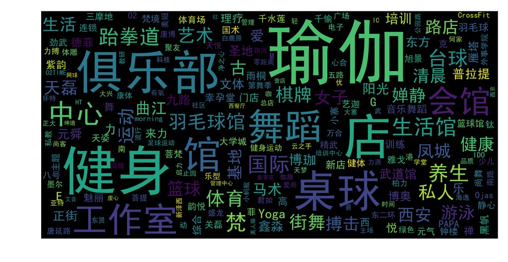

#### **2.哑变量处理**

对于第一部分提取得到的标题、团购内容、预约说明、温馨提示等字段中的关键词数据，可以编制38个哑变量，分别为：瑜伽、健身、桌球、舞蹈、梵、国际、养生、台球、跆拳道、羽毛球馆（标题）；体验、卡、健身、套餐、课、私教、桌球、课程、舞蹈、黑八、跆拳道（团购内容）；消费、保留、提前、排号、等位、高峰、无需、准时（预约说明）；瑜伽、免费课程、体验、教练、服务、舞蹈、专业、卡、器械（温馨提示）。由此编入原数据集中，并写入至新文件dummy.csv中：

```r
## 读取数据
library(readxl)
jsf <- read_excel("Jianshenfang.xlsx")    ## 将数据读入至jsf中

## 编辑哑变量
library(stringr)

## 编辑标题关键字
jsf$yujia <- str_detect(jsf$"标题", "瑜伽")
jsf$jianshen <- str_detect(jsf$"标题","健身")
jsf$zhuoqiu <- str_detect(jsf$"标题","桌球")
jsf$wudao <- str_detect(jsf$"标题","舞蹈")
jsf$fan <- str_detect(jsf$"标题","梵")
jsf$guoji <- str_detect(jsf$"标题","国际")
jsf$yangsheng <- str_detect(jsf$"标题","养生")
jsf$taiqiu <- str_detect(jsf$"标题","台球")
jsf$taiquandao <- str_detect(jsf$"标题","跆拳道")
jsf$yumaoqiuguan <- str_detect(jsf$"标题","羽毛球馆")

## 编辑温馨提示关键字
jsf$yujia1 <- str_detect(jsf$"温馨提示", "瑜伽")
jsf$mianfeikecheng <- str_detect(jsf$"温馨提示", "免费课程")
jsf$tiyan <- str_detect(jsf$"温馨提示", "体验")
jsf$jiaolian <- str_detect(jsf$"温馨提示", "教练")
jsf$fuwu <- str_detect(jsf$"温馨提示", "服务")
jsf$wudao1 <- str_detect(jsf$"温馨提示", "舞蹈")
jsf$zhuanye <- str_detect(jsf$"温馨提示", "专业")
jsf$ka <- str_detect(jsf$"温馨提示", "卡")
jsf$qixie <- str_detect(jsf$"温馨提示", "器械")

## 编辑预约说明关键字
jsf$xiaofei <- str_detect(jsf$"预约说明", "消费")
jsf$baoliu <- str_detect(jsf$"预约说明", "保留")
jsf$tiqian <- str_detect(jsf$"预约说明", "提前")
jsf$paihao <- str_detect(jsf$"预约说明", "排号")
jsf$dengwei <- str_detect(jsf$"预约说明", "等位")
jsf$gaofeng <- str_detect(jsf$"预约说明", "高峰")
jsf$wuxu <- str_detect(jsf$"预约说明", "无需")
jsf$zhunshi <- str_detect(jsf$"预约说明", "准时")

## 编辑团购内容关键字
jsf$tiyan1 <- str_detect(jsf$"团购内容", "体验")
jsf$ka1 <- str_detect(jsf$"团购内容", "卡")
jsf$jianshen1 <- str_detect(jsf$"团购内容", "健身")
jsf$taocan <- str_detect(jsf$"团购内容", "套餐")
jsf$ke <- str_detect(jsf$"团购内容", "课")
jsf$sijiao <- str_detect(jsf$"团购内容", "私教")
jsf$zhuoqiu1 <- str_detect(jsf$"团购内容", "桌球")
jsf$kechegn <- str_detect(jsf$"团购内容", "课程")
jsf$wudao2 <- str_detect(jsf$"团购内容", "舞蹈")
jsf$heiba <- str_detect(jsf$"团购内容", "黑八")
jsf$taiquandao1 <- str_detect(jsf$"团购内容", "跆拳道")

## 将得到的新数据集写入dummy.csv文件中
library("readr")
write_excel_csv(jsf, "dummy.csv")
```

#### **3.时间数据处理**

关注到时间型数据不能直接用于模型建立的数据会对结果产生较大影响，需要对这些变量进行数值型转换，首先处理有效期这一变量。

**(1) 有效期数据的初步处理**  
为了方便，先更改预设的语系：

```r
Sys.setlocale(category = "LC_ALL", locale = "Chinese")    ## 更改预设语系
```

然后从数据集中提取出有效期的数据，其中以月份数作为有效期时长的单位：

```r
## 提取有效期
jsf1 <- subset(jsf, jsf$"有效期" != "NA")    ## 删除有效期为空的数据
start.year <- as.numeric(substr(jsf1$"有效期", 1, 4))    ## 记录有效期为数值数据，下同
start.month <- as.numeric(substr(jsf1$"有效期", 6, 7))
end.year <- as.numeric(substr(jsf1$"有效期", 13, 16))
end.month <- as.numeric(substr(jsf1$"有效期", 18, 19))

## 以月份数作为单位计算时长
duration.month <- (end.year - start.year) * 12 + (end.month - start.month)
```

完成后查看分布并将数据写入新的文档duration.csv中：

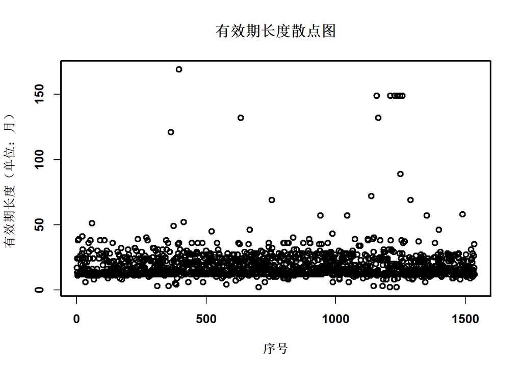

```r
## 查看有效期长度的分布情况
opar <- par(no.readonly = T)    ## 保存绘图原格式
par(font.main = 2, font.axis = 2, font.lab = 2, lwd = 2)    ## 设置绘图格式
plot(duration.month, main = "有效期长度散点图", xlab = "序号", ylab = "有效期长度（单位：月）")    ## 绘制散点图
```

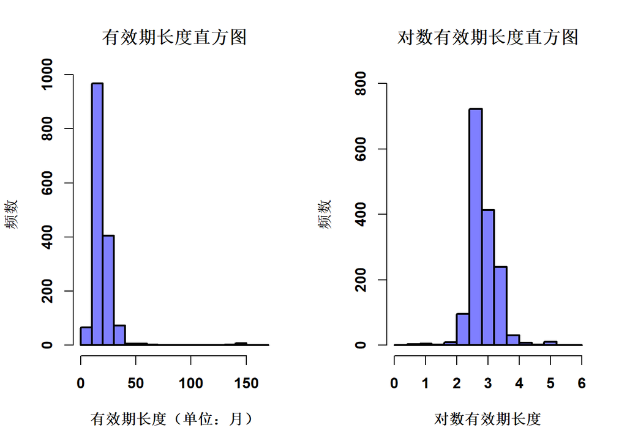

```r
par(opar)    ## 格式复位

par(mfrow = c(1, 2), font.main = 2, font.axis = 2, font.lab = 2, lwd = 2)    ## 设置绘图格式
hist(duration.month, main = "有效期长度直方图", col = "#7F7FFF", xlab = "有效期长度（单位：月）", ylab = "频数")    ## 绘制直方图
hist(log(duration.month), main = "对数有效期长度直方图", col = "#7F7FFF", xlab = "对数有效期长度", ylab = "频数", breaks = seq(0, 6, 0.4), ylim = c(0, 800))    ## 绘制对数直方图
```

```r
## 将整理后的数据写入至文件duration.csv中
library("readr")
write_excel_csv(jsf1,"duration.csv")
```

可以发现对数有效期长度直方图还是比较类似正态分布的，但相比于正态分布，该分布的中心更为聚集，表明有效期具有一个行业上的标准值。分析认为健身卡的有效期对于团购数会产生影响，因此提取出有效期长度命名为duration，单位为月份。可以看到，有效期大多分布在10到30个月之间，也即一到两年。

**(2) 有效期数据的深入处理**  
对于有效期的处理，首先先将字符型的持续时间分成两个时间型的变量（有效期开始时间和结束时间），求出有效期的持续长度。考虑到季度可能会影响团购数量，例如，夏天可能会有更多人团购游泳卡，因此另外设立两个新变量，分别是开始时间所在季度和结束时间所在季度。然后额外设立四个哑变量，分别是q1、q2、q3和q4，以记录有效期是否跨过了这四个季度。例如，若有效期为2016年2月到2017年10月，则这四个变量的取值都应为1。除此以外，考虑到时间与宏观经济可能会间接影响到购买欲望，还需取得有效期开始年份这一变量。对此处理如下：

```r
library(foreign)
jsf_dummy <- read.csv("dummy(2).csv")    ## jsf_dummy为添加哑变量后的原始数据集

## 删除有效期和规格中的缺省值
jsf_dummy <- subset(jsf_dummy, jsf_dummy$"规格" != "NA")
jsf_dummy <- subset(jsf_dummy, jsf_dummy$"有效期" != "NA")

attach(jsf_dummy)

## 用平均数代替评分中的NA
library(psych)
describe(jsf_dummy$"评分")
```

```
##    vars   n mean   sd median trimmed mad min max range  skew kurtosis   se
## X1    1 412  4.7 0.65      5    4.85   0   1   5     4 -3.42     14.5 0.03
```

```r
jsf_dummy$"评分"[is.na(jsf_dummy$"评分")] <- 4.69

## 用0代替评论数中的NA
jsf_dummy$"评论数"[is.na(jsf_dummy$"评论数")] <- 0


## 用中位数代替价格中的NA（极端值太多，平均值过高）
describe(jsf_dummy$"团购价格.元.")
```

```
##    vars    n   mean      sd median trimmed    mad min   max range skew
## X1    1 1418 790.44 1843.45    188  363.88 212.75   4 21000 20996 5.26
##    kurtosis    se
## X1    36.09 48.95
```

```r
jsf_dummy$"团购价格.元."[is.na(jsf_dummy$"团购价格.元.")] <- 188


## 起始与终止时间格式化
jsf_dummy$start <- substr(jsf_dummy$"有效期", 1, 11)
jsf_dummy$end <- substr(jsf_dummy$"有效期", 13, 23)

library(stringr)
jsf_dummy$start <- str_replace(jsf_dummy$start, "年", "-")
jsf_dummy$start <- str_replace(jsf_dummy$start, "月", "-")
jsf_dummy$start <- str_replace(jsf_dummy$start, "日", "")

jsf_dummy$end <- str_replace(jsf_dummy$end, "年", "-")
jsf_dummy$end <- str_replace(jsf_dummy$end, "月", "-")
jsf_dummy$end <- str_replace(jsf_dummy$end, "日", "")

jsf_dummy$end <- as.Date(jsf_dummy$end)
jsf_dummy$start <- as.Date(jsf_dummy$start)

## 起始与终止季度
jsf_dummy$sq <- quarters(jsf_dummy$start)
jsf_dummy$eq <- quarters(jsf_dummy$end)
jsf_dummy$sqn <- substr(jsf_dummy$sq, 2, 2)
jsf_dummy$eqn <- substr(jsf_dummy$eq, 2, 2)

## 求出经历时间（duration）
jsf_dummy$dura <- jsf_dummy$end - jsf_dummy$start
jsf_dummy$dura <- as.numeric(jsf_dummy$dura)

jsf_dummy$q1 <- 0
jsf_dummy$q2 <- 0
jsf_dummy$q3 <- 0
jsf_dummy$q4 <- 0

## 获取年份
library(lubridate)
jsf_dummy$ys <- year(jsf_dummy$start)
jsf_dummy$ys <- as.numeric(jsf_dummy$ys)
jsf_dummy$yn <- year(jsf_dummy$end)
jsf_dummy$yn <- as.numeric(jsf_dummy$yn)

## 对于跨一年的，其经历的季度为开始季度到第一年第四季度，再加上第二年初到结束季度
jsf_dummy$q1[jsf_dummy$sqn == 1 & jsf_dummy$ys == jsf_dummy$yn - 1] <- 1
jsf_dummy$q2[jsf_dummy$sqn <= 2 & jsf_dummy$ys == jsf_dummy$yn - 1] <- 1
jsf_dummy$q3[jsf_dummy$sqn <= 3 & jsf_dummy$ys == jsf_dummy$yn - 1] <- 1
jsf_dummy$q4[jsf_dummy$sqn <= 4 & jsf_dummy$ys == jsf_dummy$yn - 1] <- 1
jsf_dummy$q1[jsf_dummy$eqn >= 1 & jsf_dummy$ys == jsf_dummy$yn - 1] <- 1
jsf_dummy$q2[jsf_dummy$eqn >= 2 & jsf_dummy$ys == jsf_dummy$yn - 1] <- 1
jsf_dummy$q3[jsf_dummy$eqn >= 3 & jsf_dummy$ys == jsf_dummy$yn - 1] <- 1
jsf_dummy$q4[jsf_dummy$eqn >= 4 & jsf_dummy$ys == jsf_dummy$yn - 1] <- 1

## 跨两年及以上的，四个季度都经历
jsf_dummy$q1[jsf_dummy$yn - jsf_dummy$ys >= 2] <- 1
jsf_dummy$q2[jsf_dummy$yn - jsf_dummy$ys >= 2] <- 1
jsf_dummy$q3[jsf_dummy$yn - jsf_dummy$ys >= 2] <- 1
jsf_dummy$q4[jsf_dummy$yn - jsf_dummy$ys >= 2] <- 1

## 同一年的，经历季度为开始季度到结束季度
jsf_dummy$q1[jsf_dummy$sqn == 1 & jsf_dummy$ys == jsf_dummy$yn] <- 1
jsf_dummy$q2[jsf_dummy$sqn <= 2 & jsf_dummy$eqn >= 2 & jsf_dummy$ys == jsf_dummy$yn] <- 1
jsf_dummy$q3[jsf_dummy$sqn <= 3 & jsf_dummy$eqn >= 3 & jsf_dummy$ys == jsf_dummy$yn] <- 1
jsf_dummy$q4[jsf_dummy$eqn == 4 & jsf_dummy$ys == jsf_dummy$yn] <- 1

## 清理NA
jsf_dummy$yujia1[is.na(jsf_dummy$yujia1)] <- FALSE
jsf_dummy$mianfeikecheng[is.na(jsf_dummy$mianfeikecheng)] <- FALSE
jsf_dummy$tiyan[is.na(jsf_dummy$tiyan)] <- FALSE
jsf_dummy$jiaolian[is.na(jsf_dummy$jiaolian)] <- FALSE
jsf_dummy$fuwu[is.na(jsf_dummy$fuwu)] <- FALSE
jsf_dummy$wudao1[is.na(jsf_dummy$wudao1)] <- FALSE
jsf_dummy$zhuanye[is.na(jsf_dummy$zhuanye)] <- FALSE
jsf_dummy$ka[is.na(jsf_dummy$ka)] <- FALSE
jsf_dummy$qixie[is.na(jsf_dummy$qixie)] <- FALSE

## 设立新变量guige，用以描述规格大小，分为“多于一次”和“一次”两个类别
jsf_dummy$guige <- 1
jsf_dummy$guige[jsf_dummy$"规格" == "1次" | jsf_dummy$"规格" == "1份"] <- 0
jsf_dummy$guige <- factor(jsf_dummy$guige, levels = c(0, 1), labels = c("1次", "多于1次"))
table(jsf_dummy$guige)
```

```
##
##     1次 多于1次
##     746     672
```

```r
## 删除一些已经从中提取过信息的变量，生成jsf_lm，使用jsf_lm进行回归
jsf_lm <- jsf_dummy[,-1]
jsf_lm <- jsf_lm[,-1]
jsf_lm <- jsf_lm[,-4]
jsf_lm <- jsf_lm[,-5]
jsf_lm <- jsf_lm[,-5]
jsf_lm <- jsf_lm[,-5]
jsf_lm <- jsf_lm[,-5]
jsf_lm <- jsf_lm[,-5]
jsf_lm <- jsf_lm[,-43]
jsf_lm <- jsf_lm[,-43]
jsf_lm <- jsf_lm[,-45]
jsf_lm <- jsf_lm[,-45]


## 将起始和结束年变为factor变量
jsf_lm$ys[jsf_lm$ys == 2013 | jsf_lm$ys == 2014] <- 0
jsf_lm$ys[jsf_lm$ys == 2015 | jsf_lm$ys == 2016] <- 1
jsf_lm$ys[jsf_lm$ys == 2017] <- 2
jsf_lm$ys <- factor(jsf_lm$ys, levels = c(0, 1, 2), labels = c("2013-2014", "2015-2016", "2017"))

jsf_lm$yn[jsf_lm$yn >= 2020] <- 0
jsf_lm$yn[jsf_lm$yn == 2017] <- 1
jsf_lm$yn[jsf_lm$yn == 2018] <- 2
jsf_lm$yn[jsf_lm$yn == 2019] <- 3
jsf_lm$yn <- factor(jsf_lm$yn, levels = c(0, 1, 2, 3), labels = c("2020及以后", "2017", "2018", "2019"))

## 导出该文件为jsflm.csv
write.csv(jsf_lm,file <- "jsflm.csv")
```

### **四、回归模型的建立与分析**

```r
#使用AIC准则筛选变量
library(MASS)
stepAIC(lm(jsf_lm$"团购数" ~ . ,data = jsf_lm[, -1]))
```

```
## Start:  AIC=10151.79
## jsf_lm$团购数 ~ 评分 + 评论数 + 团购价格.元. + yujia + jianshen +
##     zhuoqiu + wudao + fan + guoji + yangsheng + taiqiu + taiquandao +
##     yumaoqiuguan + yujia1 + mianfeikecheng + tiyan + jiaolian +
##     fuwu + wudao1 + zhuanye + ka + qixie + xiaofei + baoliu +
##     tiqian + paihao + dengwei + gaofeng + wuxu + zhunshi + tiyan1 +
##     ka1 + jianshen1 + taocan + ke + sijiao + zhuoqiu1 + kechegn +
##     wudao2 + heiba + taiquandao1 + sq + eq + dura + q1 + q2 +
##     q3 + q4 + ys + yn + guige
##
##
## Step:  AIC=10151.79
## jsf_lm$团购数 ~ 评分 + 评论数 + 团购价格.元. + yujia + jianshen +
##     zhuoqiu + wudao + fan + guoji + yangsheng + taiqiu + taiquandao +
##     yumaoqiuguan + yujia1 + mianfeikecheng + tiyan + jiaolian +
##     fuwu + wudao1 + zhuanye + ka + qixie + xiaofei + baoliu +
##     tiqian + paihao + dengwei + gaofeng + wuxu + zhunshi + tiyan1 +
##     ka1 + jianshen1 + taocan + ke + sijiao + zhuoqiu1 + kechegn +
##     wudao2 + heiba + taiquandao1 + sq + eq + dura + q1 + q2 +
##     q4 + ys + yn + guige
##
##
## Step:  AIC=10151.79
## jsf_lm$团购数 ~ 评分 + 评论数 + 团购价格.元. + yujia + jianshen +
##     zhuoqiu + wudao + fan + guoji + yangsheng + taiqiu + taiquandao +
##     yumaoqiuguan + yujia1 + mianfeikecheng + tiyan + jiaolian +
##     fuwu + wudao1 + zhuanye + ka + qixie + xiaofei + baoliu +
##     tiqian + paihao + dengwei + wuxu + zhunshi + tiyan1 + ka1 +
##     jianshen1 + taocan + ke + sijiao + zhuoqiu1 + kechegn + wudao2 +
##     heiba + taiquandao1 + sq + eq + dura + q1 + q2 + q4 + ys +
##     yn + guige
##
##
## Step:  AIC=10151.79
## jsf_lm$团购数 ~ 评分 + 评论数 + 团购价格.元. + yujia + jianshen +
##     zhuoqiu + wudao + fan + guoji + yangsheng + taiqiu + taiquandao +
##     yumaoqiuguan + yujia1 + mianfeikecheng + tiyan + jiaolian +
##     fuwu + wudao1 + zhuanye + ka + qixie + xiaofei + baoliu +
##     tiqian + paihao + wuxu + zhunshi + tiyan1 + ka1 + jianshen1 +
##     taocan + ke + sijiao + zhuoqiu1 + kechegn + wudao2 + heiba +
```

[output cut: 1341 more lines]

```
## - yujia1        1      2494 1713335 10094
## - qixie         1      2877 1713718 10094
## - guoji         1      3230 1714070 10094
## - sijiao        1      3235 1714076 10094
## - zhuoqiu       1      3301 1714141 10094
## - zhuoqiu1      1      3977 1714817 10095
## - q4            1      4095 1714935 10095
## - guige         1      4111 1714952 10095
## - heiba         1      5146 1715987 10096
## - yangsheng     1      7187 1718027 10097
## - 评分          1     10753 1721593 10100
## - yumaoqiuguan  1     17275 1728116 10106
## - wuxu          1     21016 1731856 10109
## - tiqian        1     21088 1731929 10109
## - 评论数        1   3973314 5684154 11794
```

```
##
## Call:
## lm(formula = jsf_lm$团购数 ~ 评分 + 评论数 + zhuoqiu + guoji +
##     yangsheng + yumaoqiuguan + yujia1 + qixie + tiqian + wuxu +
##     sijiao + zhuoqiu1 + heiba + q4 + guige, data = jsf_lm[, -1])
##
## Coefficients:
##      (Intercept)              评分            评论数       zhuoqiuTRUE
##           74.670            -8.083             9.413            -6.056
##        guojiTRUE     yangshengTRUE  yumaoqiuguanTRUE        yujia1TRUE
##            9.927            15.242            25.872            -3.793
##        qixieTRUE        tiqianTRUE          wuxuTRUE        sijiaoTRUE
##           10.120           -60.190           -60.034            -6.201
##     zhuoqiu1TRUE         heibaTRUE                q4      guige多于1次
##            8.820            11.256            24.292             3.488
```

可见，得到一个AIC为10093.41的模型，使用该模型进行回归。

```r
t1 <- lm(jsf_lm$"团购数" ~ jsf_lm$"评分" + jsf_lm$"评论数" + jsf_lm$zhuoqiu + jsf_lm$guoji + jsf_lm$yangsheng + jsf_lm$yumaoqiuguan + jsf_lm$yujia1 + jsf_lm$qixie + jsf_lm$tiqian + jsf_lm$wuxu + jsf_lm$sijiao + jsf_lm$zhuoqiu1 + jsf_lm$heiba + jsf_lm$q4 + jsf_lm$guige)
summary(t1)
```

```
##
## Call:
## lm(formula = jsf_lm$团购数 ~ jsf_lm$评分 + jsf_lm$评论数 + jsf_lm$zhuoqiu +
##     jsf_lm$guoji + jsf_lm$yangsheng + jsf_lm$yumaoqiuguan + jsf_lm$yujia1 +
##     jsf_lm$qixie + jsf_lm$tiqian + jsf_lm$wuxu + jsf_lm$sijiao +
##     jsf_lm$zhuoqiu1 + jsf_lm$heiba + jsf_lm$q4 + jsf_lm$guige)
##
## Residuals:
##     Min      1Q  Median      3Q     Max
## -300.87   -4.51   -0.99    2.77  376.91
##
## Coefficients:
##                         Estimate Std. Error t value Pr(>|t|)
## (Intercept)               74.670     23.311   3.203 0.001390 **
## jsf_lm$评分               -8.083      2.723  -2.968 0.003044 **
## jsf_lm$评论数              9.413      0.165  57.062  < 2e-16 ***
## jsf_lm$zhuoqiuTRUE        -6.056      3.682  -1.645 0.100253
## jsf_lm$guojiTRUE           9.928      6.102   1.627 0.103995
## jsf_lm$yangshengTRUE      15.242      6.281   2.427 0.015359 *
## jsf_lm$yumaoqiuguanTRUE   25.872      6.876   3.763 0.000175 ***
## jsf_lm$yujia1TRUE         -3.793      2.653  -1.430 0.153042
## jsf_lm$qixieTRUE          10.120      6.591   1.536 0.124886
## jsf_lm$tiqianTRUE        -60.190     14.479  -4.157 3.42e-05 ***
## jsf_lm$wuxuTRUE          -60.034     14.466  -4.150 3.53e-05 ***
## jsf_lm$sijiaoTRUE         -6.201      3.809  -1.628 0.103699
## jsf_lm$zhuoqiu1TRUE        8.820      4.886   1.805 0.071253 .
## jsf_lm$heibaTRUE          11.256      5.481   2.054 0.040201 *
## jsf_lm$q4                 24.292     13.261   1.832 0.067192 .
## jsf_lm$guige多于1次        3.488      1.900   1.836 0.066638 .
## ---
## Signif. codes:  0 '***' 0.001 '**' 0.01 '*' 0.05 '.' 0.1 ' ' 1
##
## Residual standard error: 34.93 on 1402 degrees of freedom
## Multiple R-squared:  0.7288, Adjusted R-squared:  0.7259
## F-statistic: 251.1 on 15 and 1402 DF,  p-value: < 2.2e-16
```

```r
library(car)
BIC(t1)
```

```
## [1] 14208.89
```

```r
vif(t1)
```

```
##         jsf_lm$评分       jsf_lm$评论数      jsf_lm$zhuoqiu
##            1.039983            1.092049            1.645445
##        jsf_lm$guoji    jsf_lm$yangsheng jsf_lm$yumaoqiuguan
##            1.012661            1.011133            1.026233
##       jsf_lm$yujia1        jsf_lm$qixie       jsf_lm$tiqian
##            1.051960            1.011162           60.760616
##         jsf_lm$wuxu       jsf_lm$sijiao     jsf_lm$zhuoqiu1
##           60.601424            1.032970            1.284159
##        jsf_lm$heiba           jsf_lm$q4        jsf_lm$guige
##            1.255986            1.003818            1.046075
```

可以看出该回归中，其中“无需”关键词的vif较大，因此考虑将其删除。

```r
t2 <- lm(jsf_lm$"团购数"~jsf_lm$"评分" + jsf_lm$"评论数" + jsf_lm$zhuoqiu + jsf_lm$guoji + jsf_lm$yangsheng + jsf_lm$yumaoqiuguan + jsf_lm$yujia1 + jsf_lm$qixie + jsf_lm$tiqian + jsf_lm$sijiao + jsf_lm$zhuoqiu1 + jsf_lm$heiba + jsf_lm$q4 + jsf_lm$guige)
summary(t2)
```

```
##
## Call:
## lm(formula = jsf_lm$团购数 ~ jsf_lm$评分 + jsf_lm$评论数 + jsf_lm$zhuoqiu +
##     jsf_lm$guoji + jsf_lm$yangsheng + jsf_lm$yumaoqiuguan + jsf_lm$yujia1 +
##     jsf_lm$qixie + jsf_lm$tiqian + jsf_lm$sijiao + jsf_lm$zhuoqiu1 +
##     jsf_lm$heiba + jsf_lm$q4 + jsf_lm$guige)
##
## Residuals:
##     Min      1Q  Median      3Q     Max
## -307.74   -5.03   -1.08    2.58  373.69
##
## Coefficients:
##                         Estimate Std. Error t value Pr(>|t|)
## (Intercept)              15.9492    18.6322   0.856  0.39214
## jsf_lm$评分              -8.3518     2.7378  -3.051  0.00233 **
## jsf_lm$评论数             9.4814     0.1651  57.432  < 2e-16 ***
## jsf_lm$zhuoqiuTRUE       -6.4934     3.7019  -1.754  0.07963 .
## jsf_lm$guojiTRUE          9.5425     6.1368   1.555  0.12018
## jsf_lm$yangshengTRUE     14.9683     6.3167   2.370  0.01794 *
## jsf_lm$yumaoqiuguanTRUE  27.8525     6.8991   4.037  5.7e-05 ***
## jsf_lm$yujia1TRUE        -3.9454     2.6679  -1.479  0.13941
## jsf_lm$qixieTRUE          9.7942     6.6282   1.478  0.13972
## jsf_lm$tiqianTRUE        -0.7046     2.0542  -0.343  0.73163
## jsf_lm$sijiaoTRUE        -6.2646     3.8305  -1.635  0.10218
## jsf_lm$zhuoqiu1TRUE       8.3437     4.9127   1.698  0.08966 .
## jsf_lm$heibaTRUE         11.7518     5.5112   2.132  0.03315 *
## jsf_lm$q4                24.7128    13.3373   1.853  0.06410 .
## jsf_lm$guige多于1次       3.5384     1.9111   1.851  0.06431 .
## ---
## Signif. codes:  0 '***' 0.001 '**' 0.01 '*' 0.05 '.' 0.1 ' ' 1
##
## Residual standard error: 35.13 on 1403 degrees of freedom
## Multiple R-squared:  0.7254, Adjusted R-squared:  0.7227
## F-statistic: 264.8 on 14 and 1403 DF,  p-value: < 2.2e-16
```

```r
library(car)
BIC(t2)
```

```
## [1] 14218.94
```

```r
vif(t2)
```

```
##         jsf_lm$评分       jsf_lm$评论数      jsf_lm$zhuoqiu
##            1.039393            1.081202            1.644097
##        jsf_lm$guoji    jsf_lm$yangsheng jsf_lm$yumaoqiuguan
##            1.012427            1.011021            1.021289
##       jsf_lm$yujia1        jsf_lm$qixie       jsf_lm$tiqian
##            1.051758            1.011018            1.209003
##       jsf_lm$sijiao     jsf_lm$zhuoqiu1        jsf_lm$heiba
##            1.032954            1.283450            1.255389
##           jsf_lm$q4        jsf_lm$guige
##            1.003760            1.046033
```

删除桌球、国际、瑜伽、器械、私教、提前预约变量等再行尝试。

```r
t3 <- lm(jsf_lm$"团购数" ~ jsf_lm$"评分" + jsf_lm$"评论数" + jsf_lm$yangsheng + jsf_lm$yumaoqiuguan + jsf_lm$guige)
summary(t3)
```

```
##
## Call:
## lm(formula = jsf_lm$团购数 ~ jsf_lm$评分 + jsf_lm$评论数 + jsf_lm$yangsheng +
##     jsf_lm$yumaoqiuguan + jsf_lm$guige)
##
## Residuals:
##     Min      1Q  Median      3Q     Max
## -311.75   -4.11   -0.26    0.74  373.71
##
## Coefficients:
##                         Estimate Std. Error t value Pr(>|t|)
## (Intercept)               41.786     12.828   3.257  0.00115 **
## jsf_lm$评分               -8.854      2.707  -3.271  0.00110 **
## jsf_lm$评论数              9.533      0.160  59.590  < 2e-16 ***
## jsf_lm$yangshengTRUE      14.672      6.321   2.321  0.02042 *
## jsf_lm$yumaoqiuguanTRUE   28.174      6.864   4.104 4.28e-05 ***
## jsf_lm$guige多于1次        3.854      1.887   2.042  0.04132 *
## ---
## Signif. codes:  0 '***' 0.001 '**' 0.01 '*' 0.05 '.' 0.1 ' ' 1
##
## Residual standard error: 35.29 on 1412 degrees of freedom
## Multiple R-squared:  0.7212, Adjusted R-squared:  0.7202
## F-statistic: 730.5 on 5 and 1412 DF,  p-value: < 2.2e-16
```

```r
library(car)
BIC(t3)
```

```
## [1] 14175.35
```

```r
vif(t3)
```

```
##         jsf_lm$评分       jsf_lm$评论数    jsf_lm$yangsheng
##            1.006946            1.006326            1.003413
## jsf_lm$yumaoqiuguan        jsf_lm$guige
##            1.001955            1.011089
```

可以发现，剩余变量全部显著。评分对于团购数的影响是负的，这与常识不符。评论数、养生、羽毛球馆、规格与团购数存在正相关的关系。其中，评分变量与常识不符，因此单独进行回归看看结果。

```r
t4 <- lm(jsf_lm$"团购数" ~ jsf_lm$"评分")
summary(t4)
```

```
##
## Call:
## lm(formula = jsf_lm$团购数 ~ jsf_lm$评分)
##
## Residuals:
##    Min     1Q Median     3Q    Max
## -73.30 -19.19 -18.19  -8.48 953.92
##
## Coefficients:
##             Estimate Std. Error t value Pr(>|t|)
## (Intercept)   90.505     23.926   3.783 0.000162 ***
## jsf_lm$评分  -15.206      5.085  -2.990 0.002837 **
## ---
## Signif. codes:  0 '***' 0.001 '**' 0.01 '*' 0.05 '.' 0.1 ' ' 1
##
## Residual standard error: 66.53 on 1416 degrees of freedom
## Multiple R-squared:  0.006274,   Adjusted R-squared:  0.005573
## F-statistic: 8.941 on 1 and 1416 DF,  p-value: 0.002837
```

单独对评分进行回归，发现结果仍旧为负数。可能的原因为，各商家评分较为接近，参考意义不大，因此人们购买时较少关注团购评分而更多关注团购内容等因素。这也能从回归模型中得到体现，如在模型中“羽毛球馆”关键词是非常显著的。从下图中也可以看出大部分商家的评分均处于4~5之间，也符合本解释。

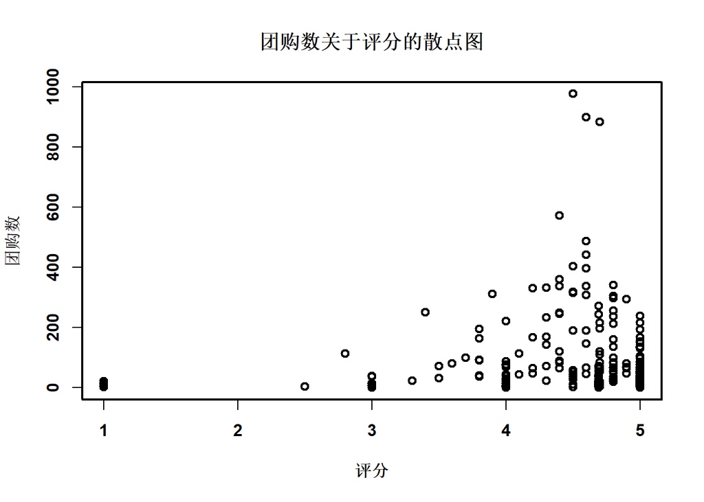

```r
par(font.main = 2, font.axis = 2, font.lab = 2, lwd = 2)    ## 设置绘图格式
plot(jsf_lm$"团购数" ~ jsf_lm$"评分", main = "团购数关于评分的散点图", xlab = "评分", ylab = "团购数")
```

```r
par(opar)    ## 格式复位
```

```r
# 读取数据
library(readxl)
jsf0 <- read_excel("Jianshenfang-2.xlsx")

# 删除部分字段
jsf2 <- jsf0[, -1]
jsf2 <- jsf2[, -43]
jsf2 <- jsf2[, -43]
jsf2 <- jsf2[, -48]
jsf2 <- jsf2[, -48]
jsf2 <- jsf2[, -48]

lm.jsf <- lm(jsf2$"团购数" ~ . , data = jsf2)
# 使用MASS包下stepAIC函数进行子集选择
# library(MASS)
# jsf.aic <- stepAIC(lm.jsf)

n <- length(jsf2[,1])

AIC(lm.jsf)    #AIC
```

```
## [1] -74397.56
```

```r
AIC(lm.jsf, k = log(n))    #BIC
```

```
## [1] -74489.56
```

```r
logit.aic <- step(lm.jsf, k = 2, trace = 0, direction = "both")
summary(logit.aic)
```

```
##
## Call:
## lm(formula = jsf2$团购数 ~ 团购数 + 评论数 + yumaoqiuguan, data = jsf2)
##
## Residuals:
##        Min         1Q     Median         3Q        Max
## -3.481e-11 -1.000e-14 -1.000e-14 -1.000e-15  1.645e-12
##
## Coefficients:
##                    Estimate Std. Error    t value Pr(>|t|)
## (Intercept)       3.170e-13  2.657e-14  1.193e+01  < 2e-16 ***
## 团购数            1.000e+00  7.124e-16  1.404e+15  < 2e-16 ***
## 评论数            3.167e-14  8.063e-15  3.928e+00 8.99e-05 ***
## yumaoqiuguanTRUE -1.264e-12  1.860e-13 -6.796e+00 1.58e-11 ***
## ---
## Signif. codes:  0 '***' 0.001 '**' 0.01 '*' 0.05 '.' 0.1 ' ' 1
##
## Residual standard error: 9.514e-13 on 1414 degrees of freedom
## Multiple R-squared:      1,  Adjusted R-squared:      1
## F-statistic: 2.323e+30 on 3 and 1414 DF,  p-value: < 2.2e-16
```

```r
logit.bic <- step(lm.jsf, k = log(n), trace = 0, direction = "both")
summary(logit.bic)
```

```
##
## Call:
## lm(formula = jsf2$团购数 ~ 团购数 + 评分 + 评论数 + 团购价格.元. +
##     yujia + jianshen + zhuoqiu + wudao + fan + guoji + yangsheng +
##     taiquandao + yumaoqiuguan + yujia1 + tiyan + jiaolian + fuwu +
##     zhuanye + ka + qixie + xiaofei + baoliu + tiqian + paihao +
##     wuxu + zhunshi + tiyan1 + ka1 + jianshen1 + taocan + ke +
##     sijiao + zhuoqiu1 + kechegn + wudao2 + heiba + taiquandao1 +
##     dura + q1 + q2 + q4 + ls, data = jsf2)
##
## Residuals:
##        Min         1Q     Median         3Q        Max
## -3.463e-11 -3.700e-14 -3.000e-15  3.000e-14  1.808e-12
##
## Coefficients:
##                    Estimate Std. Error    t value Pr(>|t|)
## (Intercept)       1.202e-12  8.201e-13  1.465e+00    0.143
## 团购数            1.000e+00  7.582e-16  1.319e+15  < 2e-16 ***
## 评分             -5.308e-14  7.594e-14 -6.990e-01    0.485
## 评论数            3.360e-14  8.397e-15  4.001e+00 6.65e-05 ***
## 团购价格.元.      5.127e-19  1.521e-17  3.400e-02    0.973
## yujiaTRUE        -5.980e-15  7.805e-14 -7.700e-02    0.939
## jianshenTRUE      1.016e-14  8.991e-14  1.130e-01    0.910
## zhuoqiuTRUE      -2.081e-14  1.107e-13 -1.880e-01    0.851
## wudaoTRUE        -7.942e-15  1.012e-13 -7.800e-02    0.937
## fanTRUE          -7.793e-15  1.212e-13 -6.400e-02    0.949
## guojiTRUE         3.145e-14  1.727e-13  1.820e-01    0.856
## yangshengTRUE     4.731e-14  1.789e-13  2.640e-01    0.792
## taiquandaoTRUE   -3.550e-14  2.492e-13 -1.420e-01    0.887
## yumaoqiuguanTRUE -1.312e-12  2.044e-13 -6.417e+00 1.91e-10 ***
## yujia1TRUE       -8.174e-15  8.382e-14 -9.800e-02    0.922
## tiyanTRUE        -2.494e-15  8.757e-14 -2.800e-02    0.977
## jiaolianTRUE     -8.948e-15  1.193e-13 -7.500e-02    0.940
## fuwuTRUE          2.820e-14  1.000e-13  2.820e-01    0.778
## zhuanyeTRUE       4.860e-14  1.294e-13  3.760e-01    0.707
## kaTRUE           -6.444e-15  9.444e-14 -6.800e-02    0.946
## qixieTRUE         1.183e-14  2.033e-13  5.800e-02    0.954
## xiaofeiTRUE       1.232e-14  3.841e-13  3.200e-02    0.974
## baoliuTRUE        2.574e-14  1.807e-13  1.420e-01    0.887
## tiqianTRUE       -4.312e-13  5.579e-13 -7.730e-01    0.440
```

[output cut: 10 more lines]

```
## kechegnTRUE       2.950e-14  1.515e-13  1.950e-01    0.846
## wudao2TRUE       -1.280e-14  1.372e-13 -9.300e-02    0.926
## heibaTRUE         4.361e-14  1.527e-13  2.860e-01    0.775
## taiquandao1TRUE   8.549e-15  2.152e-13  4.000e-02    0.968
## dura              5.139e-17  6.820e-17  7.540e-01    0.451
## q1               -3.460e-13  4.279e-13 -8.090e-01    0.419
## q2               -2.596e-13  4.177e-13 -6.210e-01    0.534
## q4                3.488e-13  4.613e-13  7.560e-01    0.450
## ls               -3.696e-15  1.352e-14 -2.730e-01    0.785
## ---
## Signif. codes:  0 '***' 0.001 '**' 0.01 '*' 0.05 '.' 0.1 ' ' 1
##
## Residual standard error: 9.625e-13 on 1375 degrees of freedom
## Multiple R-squared:      1,  Adjusted R-squared:      1
## F-statistic: 1.621e+29 on 42 and 1375 DF,  p-value: < 2.2e-16
```

### **五、小组分工**

**Group1**小组成员分工如下：  
组长 李云帆：领导小组讨论，提取关键词，进行词频分析和词云的编写；  
组员 王玉世：时间和数值类型数据转换，回归模型分析；  
组员 施俞晨：分类关键词，提取有效期，编辑哑变量，回归模型分析；  
组员 邓淇升：修改代码，整合数据文件，编辑小组报告。